# Применение регрессии

Ekaterina Vostokova

2025-01-17

Основная цель задания - оценить общий (total) эффект физической активности в отношении гликированного гемоглобина (Hb1Ac).

## Вопрос 1. Оценка физической активности

Каким образом вы будете оценивать физическую активность респондентов? Есть ли у вас предварительные предположения относительно того, каким образом выбранный вами пока- затель может быть ассоциирован с гликированным гемоглобином?

В датасете есть ряд переменных, характеризующих физическую активность, таких как PAQ605 (интенсивная физическая активность), PAQ610 (количество дней интенсивной активности), PAD615(количество минут интенсивной активности), а также PAQ620, PAQ625, PAD630 - аналогично для активности средней интенсивности. Также есть переменные, характеризующие образ жизни, например катание на велосипеде или активный отдых.

В качестве оценки можно использовать время за неделю, потраченное на физическую активность, причем более интенсивная активность будет учитываться с более высоким коэффициентом.

Следовательно, активность будет иметь вид PAQ610 * PAD615 + PAQ640 * PAD645 + PAQ655 * PAD660 + 0.5 * (PAQ625 * PAD630 + PAQ670 * PAD675)

Предварительное ожидание - что существует ассоциация между достаточной физической активностью и снижением гликированного гемоглобина. Это предположение может быть выдвинуто через данные из физиологии, которые через уровень глюкозы предполагают подобную взаимосвязь.

## Вопрос 2.

Ковариаты для каких показателей вы включите в модель для коррекции эффекта физической активности в отношении гликированного гемоглобина? Каким образом вы будете их оценивать по имеющимся данным?

Для начала стоит обратить внимание на переменные расы (RIDRETH3), пола (RIAGENDR), возраста (RIDAGEYR), курения (SMQ040) и сопутствующих заболеваний. Также это может быть образование (DMDEDUC2), доход (INDFMIN2). Сопутствующие заболевания включают в себя астму (MCQ010, MCQ035), ХОБЛ (MCQ160O), онкологию (MCQ220), заболевания щитовидной железы (MCQ160m, MCQ170m), проблемы с сердечно-сосудистой системой (MCQ160B, MCQ160C, MCQ160E, MCQ160F)

## Вопрос 3.

Проведите необходимый эксплораторный анализ перед оценкой модели.

Для начала приведем данные к более читаемому виду, переведем все категориальные переменные в факторы.

Теперь посмотрим на описательные статистики:

| **Characteristic** | **N = 916** |
| --- | --- |
| ID |  |
| Mean (SD) | 78,750 (2,969) |
| Median (Q1-Q3) | 78,868 (76,159-81,434) |
| Min-Max | 73,557-83,724 |
| Glycohemoglobin |  |
| Mean (SD) | 5.80 (1.04) |
| Median (Q1-Q3) | 5.60 (5.30-5.90) |
| Min-Max | 4.20-13.90 |
| Age |  |
| Mean (SD) | 55 (16) |
| Median (Q1-Q3) | 56 (45-67) |
| Min-Max | 20-80 |
| Sex |  |
| Male | 539 (59%) |
| Female | 377 (41%) |
| Race |  |
| Mexican American | 101 (11%) |
| Other Hispanic | 75 (8.2%) |
| Non-Hispanic White | 463 (51%) |
| Non-Hispanic Black | 175 (19%) |
| Non-Hispanic Asian | 78 (8.5%) |
| Other | 24 (2.6%) |
| Family_income |  |
| $0-$4,999 | 23 (2.5%) |
| $5,000-$9,999 | 36 (3.9%) |
| $10,000-$14,999 | 69 (7.5%) |
| $15,000-$19,999 | 78 (8.5%) |
| $20,000-$24,999 | 73 (8.0%) |
| $25,000-$34,999 | 104 (11%) |
| $35,000-$44,999 | 100 (11%) |
| $45,000-$54,999 | 78 (8.5%) |
| $55,000-$64,999 | 54 (5.9%) |
| $65,000-$74,999 | 49 (5.3%) |
| $75,000-$99,999 | 73 (8.0%) |
| $100,000 and Over | 179 (20%) |
| Education |  |
| Less than 9th grade | 54 (5.9%) |
| 9-11th grade | 119 (13%) |
| High school graduate | 203 (22%) |
| College or AA degree | 297 (32%) |
| College graduate | 243 (27%) |
| BMI |  |
| Mean (SD) | 29 (7) |
| Median (Q1-Q3) | 28 (25-33) |
| Min-Max | 17-78 |
| Smoking |  |
| Every day | 133 (15%) |
| Some days | 31 (3.4%) |
| Not at all | 264 (29%) |
| Never | 488 (53%) |
| Activity |  |
| Mean (SD) | 59 (94) |
| Median (Q1-Q3) | 20 (0-69) |
| Min-Max | 0-643 |
| PAC |  |
| Low | 799 (87%) |
| Normal | 117 (13%) |
| Asthma |  |
| Current | 84 (9.2%) |
| In history | 60 (6.6%) |
| No | 772 (84%) |
| Thyroid_problem |  |
| Current | 94 (10%) |
| In history | 36 (3.9%) |
| No | 786 (86%) |
| Cardiovascular_diseases | 102 (11%) |
| COPD | 877 (96%) |
| Cancer | 812 (89%) |
| Diabetes | 772 (84%) |

И проведем эксплораторный анализ.

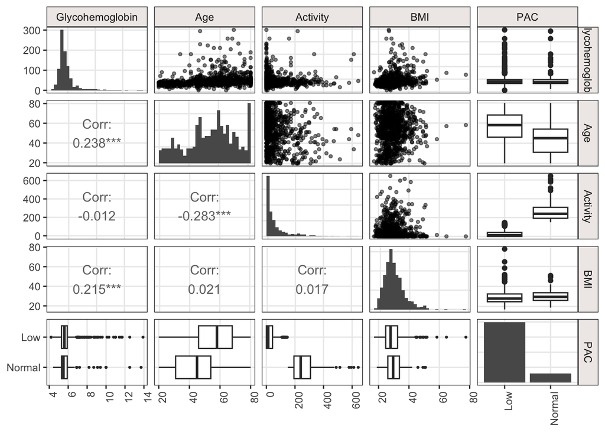

Здесь мы не видим корреляции между уровнем гликированного гемоглобина и активностью.

## Вопрос 4.

Оцените модель для зависимости гликированного гемоглобина от выбранного вами показателя физической активности без ковариат и с ними. Проведите необходимую диагностику этих моделей – требует ли что-либо коррекции и почему? В случае необходимости коррекции по результатам диагностики сделайте ее.

Модель без ковариат

```
##
## Call:
## lm(formula = Glycohemoglobin ~ Activity, data = cleaned_data)
##
## Residuals:
##     Min      1Q  Median      3Q     Max
## -1.6102 -0.5090 -0.2102  0.1131  8.0898
##
## Coefficients:
##               Estimate Std. Error t value Pr(>|t|)
## (Intercept)  5.8102448  0.0403766 143.901   <2e-16 ***
## Activity    -0.0001296  0.0003643  -0.356    0.722
## ---
## Signif. codes:  0 '***' 0.001 '**' 0.01 '*' 0.05 '.' 0.1 ' ' 1
##
## Residual standard error: 1.036 on 914 degrees of freedom
## Multiple R-squared:  0.0001384,  Adjusted R-squared:  -0.0009556
## F-statistic: 0.1265 on 1 and 914 DF,  p-value: 0.7222
```

```
## # A tibble: 2 × 7
##   term         estimate std.error statistic p.value  conf.low conf.high
##   <chr>           <dbl>     <dbl>     <dbl>   <dbl>     <dbl>     <dbl>
## 1 (Intercept)  5.81      0.0404     144.      0      5.73      5.89
## 2 Activity    -0.000130  0.000364    -0.356   0.722 -0.000845  0.000585
```

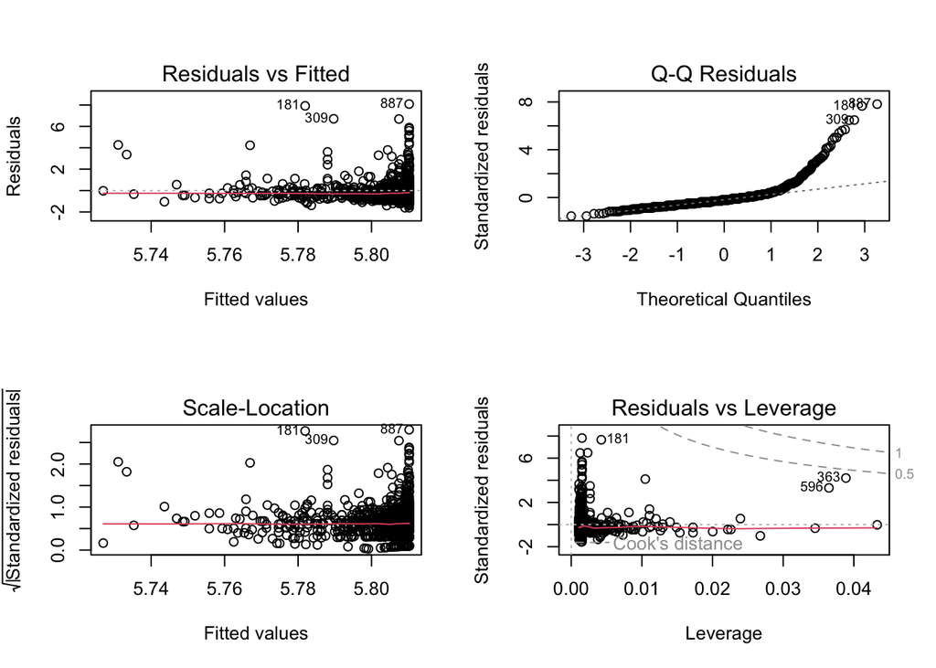

На графиках мы можем наблюдать ряд фактов. Распределение остатков ненормально (график Q-Q Residuals). Наблюдаем гетероскедастичность (Scale-Location). Видим возможные выбросы (Residuals vs Leverage).

Пробуем скорректировать модель:

| term | estimate | std.error | statistic | p.value | conf.low | conf.high |
| --- | --- | --- | --- | --- | --- | --- |
| (Intercept) | 5.810245 | 0.043228 | 134.410320 | 0.000000 | 5.725408 | 5.895082 |
| Activity | -0.000130 | 0.000499 | -0.259439 | 0.795355 | -0.001110 | 0.000851 |

Аналогично обрабатываем модель с ковариатами:

```
##
## Call:
## lm(formula = Glycohemoglobin ~ Activity + Race + Sex + Smoking +
##     Cardiovascular_diseases + Diabetes, data = cleaned_data)
##
## Residuals:
##     Min      1Q  Median      3Q     Max
## -2.4696 -0.3495 -0.0595  0.2349  6.7228
##
## Coefficients:
##                              Estimate Std. Error t value Pr(>|t|)
## (Intercept)                 7.215e+00  1.299e-01  55.558   <2e-16 ***
## Activity                    4.445e-04  3.003e-04   1.480   0.1392
## RaceOther Hispanic         -1.886e-01  1.250e-01  -1.509   0.1317
## RaceNon-Hispanic White     -2.018e-01  9.095e-02  -2.219   0.0267 *
## RaceNon-Hispanic Black      7.256e-02  1.027e-01   0.706   0.4801
## RaceNon-Hispanic Asian     -3.345e-05  1.247e-01   0.000   0.9998
## RaceOther                  -3.674e-01  1.862e-01  -1.973   0.0488 *
## SexFemale                   9.872e-02  5.707e-02   1.730   0.0840 .
## SmokingSome days           -6.190e-02  1.634e-01  -0.379   0.7049
## SmokingNot at all           2.031e-02  8.740e-02   0.232   0.8163
## SmokingNever               -4.603e-02  8.126e-02  -0.566   0.5712
## Cardiovascular_diseasesYes  2.360e-01  9.054e-02   2.606   0.0093 **
## DiabetesYes                -1.627e+00  7.818e-02 -20.816   <2e-16 ***
## ---
## Signif. codes:  0 '***' 0.001 '**' 0.01 '*' 0.05 '.' 0.1 ' ' 1
##
## Residual standard error: 0.8151 on 903 degrees of freedom
## Multiple R-squared:  0.388,  Adjusted R-squared:  0.3798
## F-statistic:  47.7 on 12 and 903 DF,  p-value: < 2.2e-16
```

```
## # A tibble: 13 × 7
##    term                estimate std.error statistic   p.value conf.low conf.high
##    <chr>                  <dbl>     <dbl>     <dbl>     <dbl>    <dbl>     <dbl>
##  1 (Intercept)          7.22e+0  0.130      5.56e+1 1.41e-293  6.96e+0   7.47
##  2 Activity             4.44e-4  0.000300   1.48e+0 1.39e-  1 -1.45e-4   0.00103
##  3 RaceOther Hispanic  -1.89e-1  0.125     -1.51e+0 1.32e-  1 -4.34e-1   0.0567
##  4 RaceNon-Hispanic W… -2.02e-1  0.0909    -2.22e+0 2.67e-  2 -3.80e-1  -0.0233
##  5 RaceNon-Hispanic B…  7.26e-2  0.103      7.06e-1 4.80e-  1 -1.29e-1   0.274
##  6 RaceNon-Hispanic A… -3.34e-5  0.125     -2.68e-4 1.00e+  0 -2.45e-1   0.245
##  7 RaceOther           -3.67e-1  0.186     -1.97e+0 4.88e-  2 -7.33e-1  -0.00190
##  8 SexFemale            9.87e-2  0.0571     1.73e+0 8.40e-  2 -1.33e-2   0.211
##  9 SmokingSome days    -6.19e-2  0.163     -3.79e-1 7.05e-  1 -3.83e-1   0.259
## 10 SmokingNot at all    2.03e-2  0.0874     2.32e-1 8.16e-  1 -1.51e-1   0.192
## 11 SmokingNever        -4.60e-2  0.0813    -5.66e-1 5.71e-  1 -2.06e-1   0.113
## 12 Cardiovascular_dis…  2.36e-1  0.0905     2.61e+0 9.30e-  3  5.83e-2   0.414
## 13 DiabetesYes         -1.63e+0  0.0782    -2.08e+1 6.55e- 79 -1.78e+0  -1.47
```

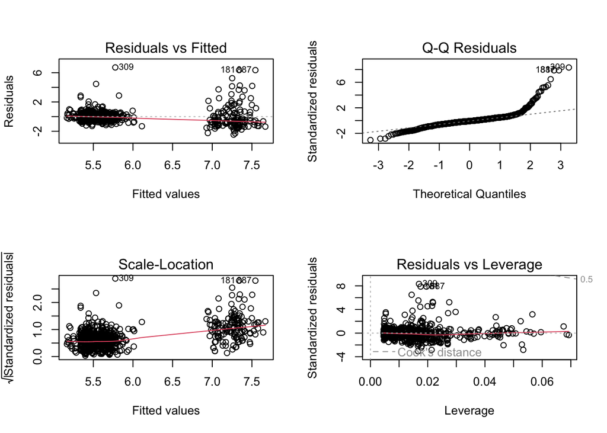

| term | estimate | std.error | statistic | p.value | conf.low | conf.high |
| --- | --- | --- | --- | --- | --- | --- |
| (Intercept) | 7.215103 | 0.172489 | 41.829451 | 0.000000 | 6.876578 | 7.553628 |
| Activity | 0.000444 | 0.000360 | 1.233423 | 0.217739 | -0.000263 | 0.001152 |
| RaceOther Hispanic | -0.188584 | 0.138808 | -1.358601 | 0.174612 | -0.461008 | 0.083839 |
| RaceNon-Hispanic White | -0.201812 | 0.112392 | -1.795613 | 0.072890 | -0.422391 | 0.018767 |
| RaceNon-Hispanic Black | 0.072561 | 0.134572 | 0.539197 | 0.589884 | -0.191550 | 0.336671 |
| RaceNon-Hispanic Asian | -0.000033 | 0.129795 | -0.000258 | 0.999794 | -0.254768 | 0.254701 |
| RaceOther | -0.367378 | 0.174161 | -2.109417 | 0.035183 | -0.709185 | -0.025571 |
| SexFemale | 0.098723 | 0.059529 | 1.658397 | 0.097585 | -0.018109 | 0.215555 |
| SmokingSome days | -0.061901 | 0.135001 | -0.458527 | 0.646684 | -0.326853 | 0.203050 |
| SmokingNot at all | 0.020310 | 0.096115 | 0.211314 | 0.832690 | -0.168325 | 0.208946 |
| SmokingNever | -0.046030 | 0.082300 | -0.559295 | 0.576099 | -0.207552 | 0.115492 |
| Cardiovascular_diseasesYes | 0.235990 | 0.123283 | 1.914215 | 0.055909 | -0.005964 | 0.477944 |
| DiabetesYes | -1.627409 | 0.137995 | -11.793246 | 0.000000 | -1.898238 | -1.356581 |

Также можем наблюдать выбросы, отклонение остатков от нормальности, гетероскедастичность. Проводим аналогичные поправки.

## Вопрос 5.

Представьте результаты оценки модели без ковариат и с ковариатами в виде точечной и интервальной оценки эффекта физической активности. Дайте им словесную интерпретацию. Какие выводы мы можем сделать, исходя из точечной оценки? А из интервальной? Как вы думаете, можно ли считать эффект клинически значимым?

Для модели без ковариат получаем Intercept = 5.8. Точечная оценка активности равна -0.000130, то есть при увеличении физической активности изменеие уровня гликированного гемоглобина меняется незначительно. Интервальная оценка - от -0.001110 до 0.000851, интервал включает 0, соответственно эффект не имеет статистической значимости. В модели с ковариатами Intercept = 7.21, точечный эффект активности 0.000444, интервальная оценка от -0.000263 до 0.001152. Это аналогично результатам модели без ковариат.

## Вопрос 6.

Проверьте гипотезу об отсутствии ассоциации между физической активностью и гликированным гемоглобином. Сделайте выводы по полученным результатам.

```
##
## Linear hypothesis test:
## Activity = 0
##
## Model 1: restricted model
## Model 2: Glycohemoglobin ~ Activity
##
## Note: Coefficient covariance matrix supplied.
##
##   Res.Df Df      F Pr(>F)
## 1    915
## 2    914  1 0.0673 0.7954
```

```
##
## Linear hypothesis test:
## Activity = 0
##
## Model 1: restricted model
## Model 2: Glycohemoglobin ~ Activity + Race + Sex + Smoking + Cardiovascular_diseases +
##     Diabetes
##
## Note: Coefficient covariance matrix supplied.
##
##   Res.Df Df      F Pr(>F)
## 1    904
## 2    903  1 1.5213 0.2177
```

Для обеих моделей p-value > 0, поэтому не можем отвергнуть нулевую гипотезу об отсутствии ассоциации.

## Вопрос 7.

Является ли пол модификатором эффекта физической активности в отношении гликированного гемоглобина? Если да, каков эффект для мужчин и женщин и насколько он отличается между ними?

| term | estimate | std.error | statistic | p.value | conf.low | conf.high |
| --- | --- | --- | --- | --- | --- | --- |
| (Intercept) | 7.210906 | 0.173859 | 41.475546 | 0.000000 | 6.869690 | 7.552121 |
| Activity | 0.000481 | 0.000420 | 1.143743 | 0.253034 | -0.000344 | 0.001305 |
| SexFemale | 0.106284 | 0.064524 | 1.647200 | 0.099865 | -0.020351 | 0.232919 |
| RaceOther Hispanic | -0.187880 | 0.140193 | -1.340147 | 0.180535 | -0.463023 | 0.087264 |
| RaceNon-Hispanic White | -0.201288 | 0.113511 | -1.773291 | 0.076518 | -0.424065 | 0.021488 |
| RaceNon-Hispanic Black | 0.073466 | 0.135981 | 0.540270 | 0.589144 | -0.193410 | 0.340343 |
| RaceNon-Hispanic Asian | 0.001376 | 0.132363 | 0.010395 | 0.991708 | -0.258400 | 0.261151 |
| RaceOther | -0.367325 | 0.174118 | -2.109627 | 0.035165 | -0.709049 | -0.025601 |
| SmokingSome days | -0.062461 | 0.135478 | -0.461040 | 0.644881 | -0.328348 | 0.203427 |
| SmokingNot at all | 0.020535 | 0.095863 | 0.214213 | 0.830430 | -0.167605 | 0.208676 |
| SmokingNever | -0.045699 | 0.082227 | -0.555768 | 0.578507 | -0.207077 | 0.115679 |
| Cardiovascular_diseasesYes | 0.236981 | 0.123462 | 1.919459 | 0.055241 | -0.005326 | 0.479288 |
| DiabetesYes | -1.626820 | 0.137444 | -11.836218 | 0.000000 | -1.896567 | -1.357072 |
| Activity:SexFemale | -0.000181 | 0.000862 | -0.209708 | 0.833943 | -0.001871 | 0.001510 |

По полученным данным не можем отвергнуть нулевую гипотезу об отсутствии различий по половому признаку.

## Вопрос 8

Соответствуют ли полученные вами результаты вашему исходному предположению?Как меняется оценка эффекта физической активности при добавлении ковариат в модель и почему?

Эффект физической активности на уровень гликированного гемоглобина не является статистически значимым ни в одной из моделей. Пол также не модифицирует эффект физической активности. Это противоречит исходным ожиданиям.